# Final code

Set up

```r
dim(df)#2078 28
```

```
[1] 2078   12
```

```r
head(df)
```

|  | Ticker | SimFinId.x | Company.Name | Industry | Fiscal.Year | Book.to.Market.Ratio | Sales.Per.Share | Return.On.Equity | Operating.Profit.Margin | Receivable.Turnover | Total.Debt.Ratio | Current.Ratio |
| --- | --- | --- | --- | --- | --- | --- | --- | --- | --- | --- | --- | --- |
| 1 | AAOI | 671827 | APPLIED OPTOELECTRONICS, INC. | Semiconductors | 2014 | 0.6749622 | 8.589539 | 0.7388186 | 0.03938704 | 5.905609 | 0.373812 | 2.329973 |
| 2 | AAOI | 671827 | APPLIED OPTOELECTRONICS, INC. | Semiconductors | 2015 | 0.5829956 | 11.486404 | 0.8047256 | 0.07082037 | 6.011681 | 0.395199 | 2.077862 |
| 3 | AAOI | 671827 | APPLIED OPTOELECTRONICS, INC. | Semiconductors | 2016 | 0.5476612 | 14.718797 | 0.8480016 | 0.08829633 | 6.723740 | 0.294535 | 2.627049 |
| 4 | AAOI | 671827 | APPLIED OPTOELECTRONICS, INC. | Semiconductors | 2017 | 0.4375648 | 18.984409 | 0.8162724 | 0.22742455 | 7.682534 | 0.264265 | 3.248529 |
| 5 | AAOI | 671827 | APPLIED OPTOELECTRONICS, INC. | Semiconductors | 2018 | 1.0855699 | 13.613529 | 0.4462494 | -0.04025947 | 4.468922 | 0.295060 | 2.509429 |
| 6 | AAPL | 111052 | APPLE INC | Computer Hardware | 2009 | 0.1655373 | 6.757720 | 1.0384956 | 0.27362778 | 17.714699 | 0.333909 | 2.742482 |

Get dividends calculated

```r
stock_save <- copy(stock)
```

calculate stock return (response variable)

[output not shown]

[output cut: 990 more lines]

calculate actual return

```r
#create a new data frame for stock return
stock_return <- first_last[!duplicated(first_last[c("Ticker","Year.adj")]), c("Ticker","Year.adj")]

#add dividends into the data frame
totDiv$Year.adj <- as.integer(totDiv$Year.adj)
totDiv$Ticker <- as.character(totDiv$Ticker)
stock_return <- left_join(stock_return, totDiv, by=c("Ticker" , "Year.adj")) ## merge annual Dividend

#calculate stock return
stock_return$logreturn <- 0
first_last$Ticker <- as.character(first_last$Ticker)
first_last$Year.adj <- as.integer(first_last$Year.adj)
for (i in 1:nrow(stock_return)) {
  thisTicker <- stock_return$Ticker[i]
  thisYear <- stock_return$Year.adj[i]
  open <- as.numeric(first_last[first_last$Ticker==thisTicker & first_last$Year.adj==thisYear, "Open"][1,])
  close <- as.numeric(first_last[first_last$Ticker==thisTicker & first_last$Year.adj==thisYear, "Close"][2,])
  div <- as.numeric(stock_return$totdiv[i])
  stock_return$logreturn[i] <- (log(close + div) - log(open))
}
dim(stock_return)#22163     4
```

```
[1] 22228     4
```

```r
for (i in 1:nrow(stock_return)) {
  thisTicker <- stock_return$Ticker[i]
  thisYear <- stock_return$Year.adj[i]
  open <- as.numeric(first_last[first_last$Ticker==thisTicker & first_last$Year.adj==thisYear, "Open"][1,])
  close <- as.numeric(first_last[first_last$Ticker==thisTicker & first_last$Year.adj==thisYear, "Close"][2,])
  div <- as.numeric(stock_return$totdiv[i])
  stock_return$actual_re[i] <- (close - open + div) / open
}
```

[output not shown]

```r
ratio_return <- left_join(df, stock_return, by =c("Ticker", "Fiscal.Year" = "Year.adj")) #return_t 和ratio_t-1 join

#get rid of unnecessary columsn
ratio_return$Year.adj.adj<- NULL

sum(is.na(ratio_return$actual_re)) #2
```

```
[1] 0
```

```r
sum(is.na(ratio_return$logreturn)) #2
```

```
[1] 0
```

```r
ratio_return <- na.omit(ratio_return)
```

########################################################Data Transformation#########################################

correlation among variables

```r
comp <- ratio_return %>% filter(Fiscal.Year > 2009) %>% group_by(Ticker) %>% mutate(nyears = n_distinct(Fiscal.Year)) %>% filter(nyears == 9) %>% select(Ticker, Fiscal.Year)
nrow(comp) #486 observations
```

```
[1] 486
```

```r
n_distinct(comp$Ticker) #54 company selected
```

```
[1] 54
```

```r
raw <- left_join(comp, ratio_return, by=c("Ticker", "Fiscal.Year"))
dim(raw) #1278 14
```

```
[1] 486  14
```

(1)Book.to.Market.Ratio

```r
cor(raw[-c(1:5)])
```

```
                        Book.to.Market.Ratio Sales.Per.Share Return.On.Equity Operating.Profit.Margin Receivable.Turnover
Book.to.Market.Ratio             1.000000000     -0.01707136       0.06128621             -0.10093440        -0.002977148
Sales.Per.Share                 -0.017071363      1.00000000       0.85197407             -0.29297846        -0.097270486
Return.On.Equity                 0.061286208      0.85197407       1.00000000             -0.32403666        -0.087616631
Operating.Profit.Margin         -0.100934405     -0.29297846      -0.32403666              1.00000000         0.257920626
Receivable.Turnover             -0.002977148     -0.09727049      -0.08761663              0.25792063         1.000000000
Total.Debt.Ratio                 0.050220638      0.35721330       0.48356768             -0.31654254        -0.038893385
Current.Ratio                   -0.033210734     -0.18026202      -0.20620772              0.27373374        -0.024711727
logreturn                       -0.054039726     -0.07577540      -0.05234351              0.07752361         0.101232679
actual_re                       -0.008328033     -0.02559800       0.01268488             -0.03318952         0.007681237
                        Total.Debt.Ratio Current.Ratio   logreturn    actual_re
Book.to.Market.Ratio          0.05022064   -0.03321073 -0.05403973 -0.008328033
Sales.Per.Share               0.35721330   -0.18026202 -0.07577540 -0.025597998
Return.On.Equity              0.48356768   -0.20620772 -0.05234351  0.012684883
Operating.Profit.Margin      -0.31654254    0.27373374  0.07752361 -0.033189521
Receivable.Turnover          -0.03889339   -0.02471173  0.10123268  0.007681237
Total.Debt.Ratio              1.00000000   -0.64567208 -0.01975995  0.028199825
Current.Ratio                -0.64567208    1.00000000  0.01074469 -0.020269060
logreturn                    -0.01975995    0.01074469  1.00000000  0.670013477
actual_re                     0.02819983   -0.02026906  0.67001348  1.000000000
```

log transformation did make the distribution more enormal

```r
summary(train$Book.to.Market.Ratio)
```

```
   Min. 1st Qu.  Median    Mean 3rd Qu.    Max.
 0.0097  0.1969  0.3056  0.6860  0.4432 43.5843
```

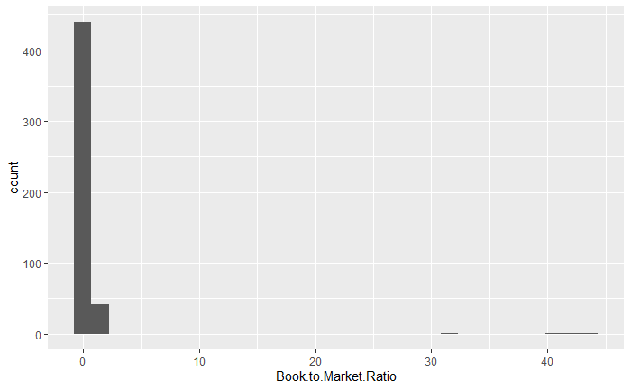

```r
#   Min. 1st Qu.  Median    Mean 3rd Qu.    Max.
# 0.0097  0.1969  0.3056  0.6860  0.4432 43.5843

#right skewed
ggplot(train) + geom_histogram(aes(x = Book.to.Market.Ratio))
```

(2)Sales.Per.Share

[figure not shown]

log transformation made the distribution normal

[figure not shown]

(3)Return.On.Equity

[figure not shown]

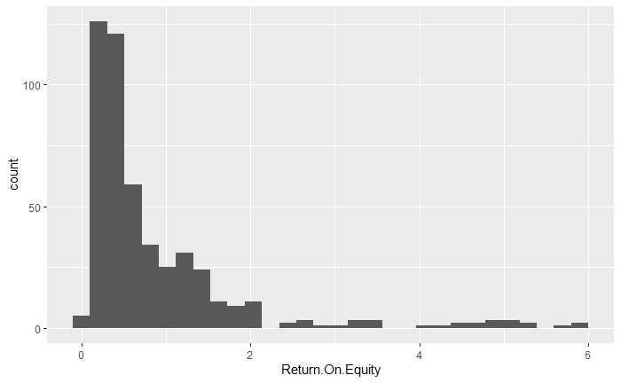

(4)Operating.Profit.Margin

[figure not shown]

still a little bit skewed but better

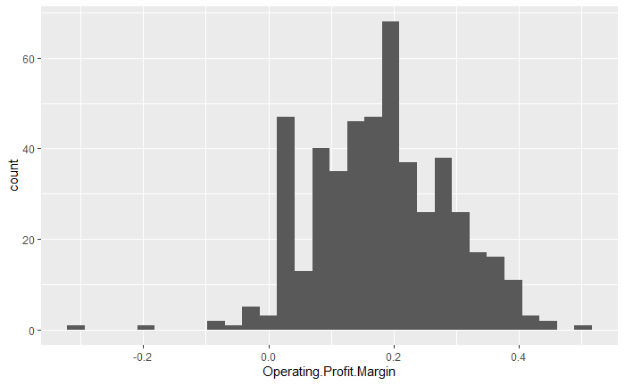

```r
#right skewed
ggplot(train) + geom_histogram(aes(x = Operating.Profit.Margin))
```

(5)Receivable.Turnover

[figure not shown]

more normal

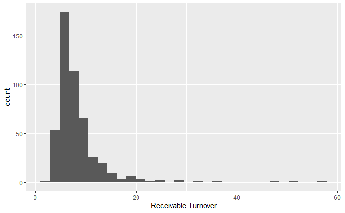

```r
#right skewed
ggplot(train) + geom_histogram(aes(x = Receivable.Turnover))
```

(6)Total.Debt.Ratio

```r
train$Receivable.Turnover.log <- log(train$Receivable.Turnover)
```

pretty normal

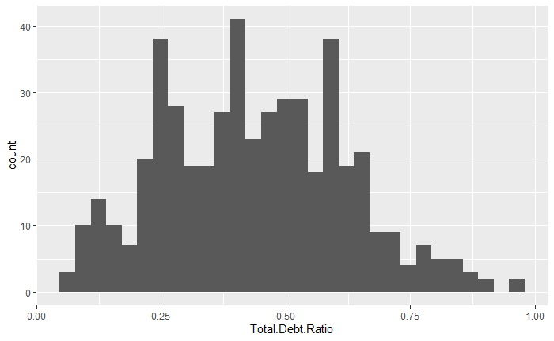

```r
#right skewed
ggplot(train) + geom_histogram(aes(x = Total.Debt.Ratio))
```

(7)Current.Ratio

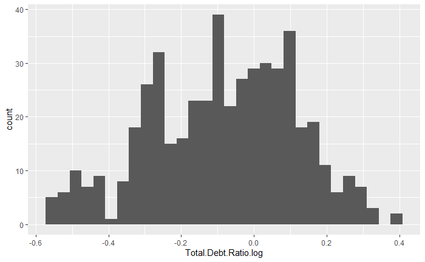

```r
ggplot(train) + geom_histogram(aes(x = Total.Debt.Ratio.log))
```

very normal after transformation

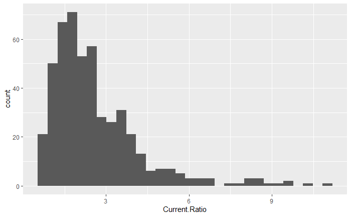

```r
#   Min. 1st Qu.  Median    Mean 3rd Qu.    Max.
# 0.6442  1.5263  2.1979  2.6038  3.2879 10.9466
#right skewed
ggplot(train) + geom_histogram(aes(x = Current.Ratio))
```

check correlation

[figure not shown]

```r
cor(train[-c(1:5)])
```

```
                            Book.to.Market.Ratio Sales.Per.Share Return.On.Equity Operating.Profit.Margin Receivable.Turnover
Book.to.Market.Ratio                 1.000000000     -0.01707136       0.06128621             -0.10093440        -0.002977148
Sales.Per.Share                     -0.017071363      1.00000000       0.85197407             -0.29297846        -0.097270486
Return.On.Equity                     0.061286208      0.85197407       1.00000000             -0.32403666        -0.087616631
Operating.Profit.Margin             -0.100934405     -0.29297846      -0.32403666              1.00000000         0.257920626
Receivable.Turnover                 -0.002977148     -0.09727049      -0.08761663              0.25792063         1.000000000
Total.Debt.Ratio                     0.050220638      0.35721330       0.48356768             -0.31654254        -0.038893385
Current.Ratio                       -0.033210734     -0.18026202      -0.20620772              0.27373374        -0.024711727
logreturn                           -0.054039726     -0.07577540      -0.05234351              0.07752361         0.101232679
actual_re                           -0.008328033     -0.02559800       0.01268488             -0.03318952         0.007681237
Book.to.Market.Ratio.log             0.583468894      0.19494563       0.09145245             -0.26751012        -0.167385684
Sales.Per.Share.log                 -0.064182381      0.81674017       0.75192460             -0.22621101        -0.027596330
Return.On.Equity.log                 0.102742657      0.64344899       0.86187563             -0.27217500        -0.012811988
Operating.Profit.Margin.log         -0.101155787     -0.29790550      -0.32858018              0.99865945         0.253249111
Receivable.Turnover.log              0.019923565     -0.15660052      -0.13038110              0.30847168         0.900672104
Total.Debt.Ratio.log                 0.054511149      0.34471816       0.45369823             -0.31644392        -0.035386284
Current.Ratio.log                   -0.019182023     -0.17659889      -0.21682136              0.30844342        -0.047279035
                            Total.Debt.Ratio Current.Ratio   logreturn    actual_re Book.to.Market.Ratio.log Sales.Per.Share.log
Book.to.Market.Ratio              0.05022064   -0.03321073 -0.05403973 -0.008328033              0.583468894         -0.06418238
Sales.Per.Share                   0.35721330   -0.18026202 -0.07577540 -0.025597998              0.194945630          0.81674017
Return.On.Equity                  0.48356768   -0.20620772 -0.05234351  0.012684883              0.091452450          0.75192460
Operating.Profit.Margin          -0.31654254    0.27373374  0.07752361 -0.033189521             -0.267510117         -0.22621101
Receivable.Turnover              -0.03889339   -0.02471173  0.10123268  0.007681237             -0.167385684         -0.02759633
Total.Debt.Ratio                  1.00000000   -0.64567208 -0.01975995  0.028199825             -0.264818751          0.46268102
Current.Ratio                    -0.64567208    1.00000000  0.01074469 -0.020269060              0.159226625         -0.24774992
logreturn                        -0.01975995    0.01074469  1.00000000  0.670013477             -0.209575011         -0.10007522
actual_re                         0.02819983   -0.02026906  0.67001348  1.000000000             -0.006132183         -0.04218069
Book.to.Market.Ratio.log         -0.26481875    0.15922663 -0.20957501 -0.006132183              1.000000000          0.08168906
Sales.Per.Share.log               0.46268102   -0.24774992 -0.10007522 -0.042180688              0.081689064          1.00000000
Return.On.Equity.log              0.50910982   -0.16468473 -0.03467688  0.037439987              0.077070624          0.72153100
Operating.Profit.Margin.log      -0.31783984    0.27526426  0.08073123 -0.032712406             -0.269948801         -0.22495649
Receivable.Turnover.log          -0.11279156    0.06010024  0.12592475  0.021710640             -0.093461077         -0.07649706
Total.Debt.Ratio.log              0.99286075   -0.67626944 -0.01666038  0.030110350             -0.237112423          0.45920461
Current.Ratio.log                -0.70575898    0.93060644  0.01176866 -0.016824353              0.252539353         -0.24612032
                            Return.On.Equity.log Operating.Profit.Margin.log Receivable.Turnover.log Total.Debt.Ratio.log
Book.to.Market.Ratio                  0.10274266                 -0.10115579              0.01992357           0.05451115
Sales.Per.Share                       0.64344899                 -0.29790550             -0.15660052           0.34471816
Return.On.Equity                      0.86187563                 -0.32858018             -0.13038110           0.45369823
Operating.Profit.Margin              -0.27217500                  0.99865945              0.30847168          -0.31644392
Receivable.Turnover                  -0.01281199                  0.25324911              0.90067210          -0.03538628
```

[output cut: 13 more lines]

```
Sales.Per.Share                   -0.17659889
Return.On.Equity                  -0.21682136
Operating.Profit.Margin            0.30844342
Receivable.Turnover               -0.04727903
Total.Debt.Ratio                  -0.70575898
Current.Ratio                      0.93060644
logreturn                          0.01176866
actual_re                         -0.01682435
Book.to.Market.Ratio.log           0.25253935
Sales.Per.Share.log               -0.24612032
Return.On.Equity.log              -0.17721465
Operating.Profit.Margin.log        0.31046933
Receivable.Turnover.log            0.05174901
Total.Debt.Ratio.log              -0.71771408
Current.Ratio.log                  1.00000000
```

########################################################Correlation Analysis ############################################

```r
write.csv(train, "capstone_repository/data/train.csv")
```

####################################################Predictive Linear regression model#################################################

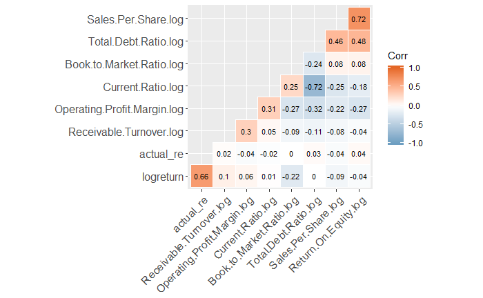

```r
ggcorrplot(corr, hc.order = TRUE, type = "lower",
   lab = TRUE, outline.col = "white",
   ggtheme = ggplot2::theme_gray,
   colors = c("#6D9EC1", "white", "#E46726"),lab_size = 3)
```

```r
model <- lm(logreturn ~ Book.to.Market.Ratio.log + Sales.Per.Share.log + Return.On.Equity.log + Operating.Profit.Margin.log + Receivable.Turnover.log + Total.Debt.Ratio.log+Current.Ratio.log, data=train[train$Fiscal.Year == 2016,])
summary(model)
```

```
Call:
lm(formula = logreturn ~ Book.to.Market.Ratio.log + Sales.Per.Share.log +
    Return.On.Equity.log + Operating.Profit.Margin.log + Receivable.Turnover.log +
    Total.Debt.Ratio.log + Current.Ratio.log, data = train[train$Fiscal.Year ==
    2016, ])

Residuals:
     Min       1Q   Median       3Q      Max
-0.49933 -0.11962 -0.01156  0.12034  0.62949

Coefficients:
                             Estimate Std. Error t value Pr(>|t|)
(Intercept)                 -0.159904   0.313612  -0.510   0.6126
Book.to.Market.Ratio.log    -0.110790   0.071345  -1.553   0.1273
Sales.Per.Share.log         -0.006936   0.065428  -0.106   0.9160
Return.On.Equity.log         0.058361   0.069842   0.836   0.4077
Operating.Profit.Margin.log -0.651641   0.430552  -1.514   0.1370
Receivable.Turnover.log      0.102746   0.072963   1.408   0.1658
Total.Debt.Ratio.log        -0.040036   0.269136  -0.149   0.8824
Current.Ratio.log            0.240810   0.095797   2.514   0.0155 *
---
Signif. codes:  0 ‘***’ 0.001 ‘**’ 0.01 ‘*’ 0.05 ‘.’ 0.1 ‘ ’ 1

Residual standard error: 0.2224 on 46 degrees of freedom
Multiple R-squared:  0.2971,    Adjusted R-squared:  0.1901
F-statistic: 2.777 on 7 and 46 DF,  p-value: 0.01704
```

```r
train2016 <- train[train$Fiscal.Year < 2016,]
test2016 <- train[train$Fiscal.Year == 2016,]

model2016 <- glm(logreturn ~ Book.to.Market.Ratio.log + Sales.Per.Share.log + Return.On.Equity.log + Operating.Profit.Margin.log + Receivable.Turnover.log + Total.Debt.Ratio.log+Current.Ratio.log, data=train2016)

distPred2016 <- predict(model2016, test2016)  # predict distance
actuals_preds2016 <- data.frame(cbind(test2016[c(1:5,14)], actuals=test2016$actual_re, predicteds=distPred2016))


actuals_preds2016[order(-actuals_preds2016$predicteds),][1:10,] %>% summarise(totreturn = mean(actuals))#good: 0.350472
```

| totreturn |
| --- |
| 0.5277509 |

```r
actuals_preds2016[order(actuals_preds2016$predicteds),][1:10,] %>% summarise(totreturn = mean(actuals))#bad: 0.2266411
```

| totreturn |
| --- |
| 0.3029431 |

[output not shown]

```r
#predict 2017
train2017 <- train[train$Fiscal.Year < 2017,]
test2017 <- train[train$Fiscal.Year == 2017,]

model2017 <- glm(logreturn ~ Book.to.Market.Ratio.log + Sales.Per.Share.log + Return.On.Equity.log + Operating.Profit.Margin.log + Receivable.Turnover.log + Total.Debt.Ratio.log+Current.Ratio.log,  data=train2017)

distPred2017 <- predict(model2017, test2017)  # predict distance
actuals_preds2017 <- data.frame(cbind(test2017[c(1:5,14)], actuals=test2017$actual_re, predicteds=distPred2017))


actuals_preds2017[order(-actuals_preds2017$predicteds),][1:5,] %>% summarise(totreturn = mean(actuals))#good: 0.03060938

actuals_preds2017[order(actuals_preds2017$predicteds),][1:5,] %>% summarise(totreturn = mean(actuals))#bad: 0.06896462
```

| totreturn |
| --- |
| 0.0552313 |

```r
NA
```

```r
train2018 <- train[train$Fiscal.Year < 2018,]
test2018 <- train[train$Fiscal.Year == 2018,]

model2018 <- glm(logreturn ~ Book.to.Market.Ratio.log + Sales.Per.Share.log + Return.On.Equity.log + Operating.Profit.Margin.log + Receivable.Turnover.log + Total.Debt.Ratio.log+Current.Ratio.log + Industry, data=train2018)

distPred2018 <- predict(model2018, test2018)  # predict distance
actuals_preds2018 <- data.frame(cbind(test2018[c(1:5,14)], actuals=test2018$actual_re, predicteds=distPred2018))


actuals_preds2018[order(-actuals_preds2018$predicteds),][1:5,] %>% summarise(totreturn = mean(actuals))#good: 0.1329313
```

| totreturn |
| --- |
| 0.1120017 |

```r
actuals_preds2018[order(actuals_preds2018$predicteds),][1:5,] %>% summarise(totreturn = mean(actuals))#bad: 0.2015754
```

| totreturn |
| --- |
| -0.2019476 |